# as8

Assignment 8: Probability Concepts

Load the Dataset and Answer the Following Questions:

1. How many null values are there in each column?

   1.1. Replace the null value of column "wheelbase" with the max value of the same column.

   1.2. Replace the null value of column "carwidth" with the Min value of the same column.

   1.3. Use Linear Interpolation to change the null value of column "carheight".

Part 1: Handling missing values & Basic concepts in Probability

Import necessary libraries, load the 'Cars.csv' dataset, display a data sample, determine dataset dimensions, and determine the summary statistics for quantitative and qualtitative columns.

```python
import pandas as pd
import numpy as np
import matplotlib.pyplot as plt
import seaborn as sns
import warnings
warnings.filterwarnings("ignore")
```

```python
df = pd.read_csv('Cars.csv')
print(df.shape)
df.head()
```

```
(205, 24)
```

|  | carname | fueltype | aspiration | doornumber | carbody | drivewheel | enginelocation | wheelbase | carlength | carwidth | ... | enginesize | fuelsystem | boreratio | stroke | compressionratio | horsepower | peakrpm | citympg | highwaympg | price |
| --- | --- | --- | --- | --- | --- | --- | --- | --- | --- | --- | --- | --- | --- | --- | --- | --- | --- | --- | --- | --- | --- |
| 0 | alfa-romero giulia | gas | std | two | convertible | rwd | front | 88.6 | 168.8 | 64.1 | ... | 130.0 | mpfi | 3.47 | 2.68 | 9.0 | 111 | 5000 | 21 | 27 | 13495.0 |
| 1 | alfa-romero stelvio | gas | std | two | convertible | rwd | front | 88.6 | 168.8 | 64.1 | ... | 130.0 | mpfi | 3.47 | 2.68 | 9.0 | 111 | 5000 | 21 | 27 | 16500.0 |
| 2 | alfa-romero Quadrifoglio | gas | std | two | hatchback | rwd | front | 94.5 | 171.2 | 65.5 | ... | 152.0 | mpfi | 2.68 | 3.47 | 9.0 | 154 | 5000 | 19 | 26 | 16500.0 |
| 3 | audi 100 ls | gas | std | four | sedan | fwd | front | 99.8 | 176.6 | 66.2 | ... | 109.0 | mpfi | 3.19 | 3.40 | 10.0 | 102 | 5500 | 24 | 30 | 13950.0 |
| 4 | audi 100ls | gas | std | four | sedan | 4wd | front | 99.4 | 176.6 | 66.4 | ... | 136.0 | mpfi | 3.19 | 3.40 | 8.0 | 115 | 5500 | 18 | 22 | 17450.0 |

5 rows × 24 columns

```python
df.describe()
```

|  | wheelbase | carlength | carwidth | carheight | curbweight | enginesize | boreratio | stroke | compressionratio | horsepower | peakrpm | citympg | highwaympg | price |
| --- | --- | --- | --- | --- | --- | --- | --- | --- | --- | --- | --- | --- | --- | --- |
| count | 194.000000 | 205.000000 | 185.000000 | 190.000000 | 205.000000 | 185.000000 | 205.000000 | 205.000000 | 205.000000 | 205.000000 | 205.000000 | 205.000000 | 205.000000 | 205.000000 |
| mean | 98.669588 | 174.049268 | 65.932973 | 53.738947 | 2555.565854 | 124.081081 | 3.329756 | 3.255415 | 10.142537 | 104.117073 | 5125.121951 | 25.219512 | 30.751220 | 13276.710571 |
| std | 5.934168 | 12.337289 | 2.113143 | 2.470452 | 520.680204 | 38.528771 | 0.270844 | 0.313597 | 3.972040 | 39.544167 | 476.985643 | 6.542142 | 6.886443 | 7988.852332 |
| min | 86.600000 | 141.100000 | 60.300000 | 47.800000 | 1488.000000 | 61.000000 | 2.540000 | 2.070000 | 7.000000 | 48.000000 | 4150.000000 | 13.000000 | 16.000000 | 5118.000000 |
| 25% | 94.500000 | 166.300000 | 64.200000 | 52.000000 | 2145.000000 | 97.000000 | 3.150000 | 3.110000 | 8.600000 | 70.000000 | 4800.000000 | 19.000000 | 25.000000 | 7788.000000 |
| 50% | 97.000000 | 173.200000 | 65.500000 | 54.100000 | 2414.000000 | 110.000000 | 3.310000 | 3.290000 | 9.000000 | 95.000000 | 5200.000000 | 24.000000 | 30.000000 | 10295.000000 |
| 75% | 101.800000 | 183.100000 | 66.600000 | 55.575000 | 2935.000000 | 141.000000 | 3.580000 | 3.410000 | 9.400000 | 116.000000 | 5500.000000 | 30.000000 | 34.000000 | 16503.000000 |
| max | 120.900000 | 208.100000 | 72.300000 | 59.800000 | 4066.000000 | 308.000000 | 3.940000 | 4.170000 | 23.000000 | 288.000000 | 6600.000000 | 49.000000 | 54.000000 | 45400.000000 |

```python
df.describe(include=['object'])
```

|  | carname | fueltype | aspiration | doornumber | carbody | drivewheel | enginelocation | enginetype | cylindernumber | fuelsystem |
| --- | --- | --- | --- | --- | --- | --- | --- | --- | --- | --- |
| count | 205 | 205 | 205 | 205 | 205 | 205 | 205 | 205 | 205 | 205 |
| unique | 147 | 2 | 2 | 2 | 5 | 3 | 2 | 7 | 7 | 8 |
| top | toyota corona | gas | std | four | sedan | fwd | front | ohc | four | mpfi |
| freq | 6 | 185 | 168 | 115 | 96 | 120 | 202 | 148 | 159 | 94 |

### Q1: How many null values are there in each column?

```python
df.isna().sum()
```

```
carname              0
fueltype             0
aspiration           0
doornumber           0
carbody              0
drivewheel           0
enginelocation       0
wheelbase           11
carlength            0
carwidth            20
carheight           15
curbweight           0
enginetype           0
cylindernumber       0
enginesize          20
fuelsystem           0
boreratio            0
stroke               0
compressionratio     0
horsepower           0
peakrpm              0
citympg              0
highwaympg           0
price                0
dtype: int64
```

```python
df['wheelbase'] = df['wheelbase'].fillna(df['wheelbase'].max())
```

```python
df['carwidth'] = df['carwidth'].fillna(df['carwidth'].min())
```

```python
df['carheight'] = df['carheight'].interpolate(method='linear')
```

```python
df['enginesize'] = df['enginesize'].fillna(df['enginesize'].mode()[0])
df.isna().sum()
```

```
carname             0
fueltype            0
aspiration          0
doornumber          0
carbody             0
drivewheel          0
enginelocation      0
wheelbase           0
carlength           0
carwidth            0
carheight           0
curbweight          0
enginetype          0
cylindernumber      0
enginesize          0
fuelsystem          0
boreratio           0
stroke              0
compressionratio    0
horsepower          0
peakrpm             0
citympg             0
highwaympg          0
price               0
dtype: int64
```

### Q2: What is the Probability that the Car is Sedan ? (1 mark)

```python
Pa = (df.carbody == 'sedan').mean();
Pa
```

```
np.float64(0.4682926829268293)
```

### Q3: What is the Probability that the car is Sedan and works with gas?

```python
Pb = (df.fueltype == 'gas').mean()
print(Pa * Pb )
```

```
0.4226055919095777
```

### Q4:What is the probability that a car is Sedan given it is a gas fuel type?

```python
(Pa * Pb) / Pb
```

```
np.float64(0.46829268292682935)
```

### Q5: Given that the car height is higer than 50, find the probability that the car engine size is greater than 130?

```python
# P(sz > 130 | height > 50)
Pa = (df.enginesize > 130).mean()
Pb = (df.carheight > 50).mean()
(Pa * Pb) / Pb
```

```
np.float64(0.28780487804878047)
```

Part 2: Probability Functions

### Q6: Load dataset 'students.csv' and show first rows, shape, and compute the skewness.

```python
df2 = pd.read_csv('students.csv')
df2.shape
```

```
(8239, 16)
```

```python
df2.head()
```

|  | stud.id | name | gender | age | height | weight | religion | nc.score | semester | major | minor | score1 | score2 | online.tutorial | graduated | salary |
| --- | --- | --- | --- | --- | --- | --- | --- | --- | --- | --- | --- | --- | --- | --- | --- | --- |
| 0 | 833917 | Gonzales, Christina | Female | 19 | 160 | 64.8 | Muslim | 1.91 | 1st | Political Science | Social Sciences | NaN | NaN | 0 | 0 | NaN |
| 1 | 898539 | Lozano, T'Hani | Female | 19 | 172 | 73.0 | Other | 1.56 | 2nd | Social Sciences | Mathematics and Statistics | NaN | NaN | 0 | 0 | NaN |
| 2 | 379678 | Williams, Hanh | Female | 22 | 168 | 70.6 | Protestant | 1.24 | 3rd | Social Sciences | Mathematics and Statistics | 45.0 | 46.0 | 0 | 0 | NaN |
| 3 | 807564 | Nem, Denzel | Male | 19 | 183 | 79.7 | Other | 1.37 | 2nd | Environmental Sciences | Mathematics and Statistics | NaN | NaN | 0 | 0 | NaN |
| 4 | 383291 | Powell, Heather | Female | 21 | 175 | 71.4 | Catholic | 1.46 | 1st | Environmental Sciences | Mathematics and Statistics | NaN | NaN | 0 | 0 | NaN |

```python
skewness = df2.skew(numeric_only=True)
print(skewness.sort_values())
```

```
score1            -0.318819
score2            -0.304878
height            -0.009244
stud.id            0.018612
salary             0.273835
nc.score           0.446834
online.tutorial    0.467502
weight             0.651004
graduated          1.403900
age                4.427823
dtype: float64
```

```python
df2.isna().sum()
```

```
stud.id               0
name                  0
gender                0
age                   0
height                0
weight                0
religion              0
nc.score              0
semester              0
major                 0
minor                 0
score1             3347
score2             3347
online.tutorial       0
graduated             0
salary             6486
dtype: int64
```

### Q7: What is the probability that the salary is greater than 20000 and less than 30000 ?

To answer this question, you should do the following:

1. Identify the distribution by
   - Plotting Histogram
   - calculate the skewness
   - Which distribution does this data follow?
2. Compute mean and std
3. Convert to Z-scores
4. Use CDF difference with the use of the right distribution function from scipy.stats

#### 1. Distribution

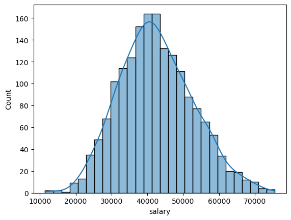

```python
sns.histplot(df2, x='salary', kde=True)
```

```python
salary_skew = df2['salary'].dropna().skew()
print(salary_skew)
```

```
0.2738351416144119
```

Since the -0.5 < salary_skew < 0.5, it is normally distributed

#### 2. mean, std

```python
print(df2['salary'].mean())
print(df2['salary'].std())
```

```
42522.112364181405
10333.139905547336
```

#### 3. Converting to Z score

```python
mu = df2['salary'].mean()
sigma = df2['salary'].std()

df2['salary_z'] = (df2['salary'] - mu) / sigma
df2[['salary', 'salary_z']].head()
```

|  | salary | salary_z |
| --- | --- | --- |
| 0 | NaN | NaN |
| 1 | NaN | NaN |
| 2 | NaN | NaN |
| 3 | NaN | NaN |
| 4 | NaN | NaN |

#### 4. CDF difference with the use of the right distribution function from scipy.stats

```python
from scipy.stats import norm

lower_bound = 20000
upper_bound = 30000

z1 = (lower_bound - mu) / sigma
z2 = (upper_bound - mu) / sigma
p = norm.cdf(z2) - norm.cdf(z1)
p
```

```
np.float64(0.09814325462173662)
```

P(20000< salary < 30000) = 9.8%

### Q8: A factory produces 200 chips with defect rate 8%. Answer the following questions:

1. What is the distribution name of this problem, based on the following questions?
2. What is the probability of getting exactly 14 defective chips?
3. At least 14 defective?
4. At most 15 defective?
5. Expected defects and standard deviation

You should use the right distribution function from scipy.stats to proceed with the answers

**1- The distribution name of this problem is `Binomial`**

```python
from scipy.stats import binom
import math
```

P(x==14)

```python
binom.pmf(14, 200, 0.08)
```

```
np.float64(0.09541156492261971)
```

P(x>=14)

```python
1 - binom.cdf(13, 200, 0.08)
```

```
np.float64(0.7357078859493741)
```

P(x<=15)

```python
binom.cdf(15, 200, 0.08)
```

```
np.float64(0.4625822359332888)
```

Expected defects and standard deviation

```python
print("Expected defects: ", 200*0.08)
print("Std: ", math.sqrt(200*0.08*0.92))
```

```
Expected defects:  16.0
Std:  3.8366652186501757
```